# Exploratory Data Analysis

#### What is the distribution of average price by vehicle model across drive type?

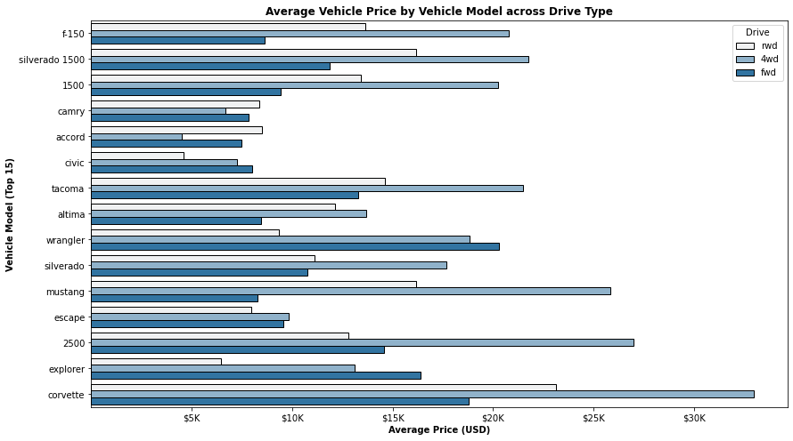

```python
# look at average vehicle price by model
plt.figure(figsize=[14, 8])
sns.barplot(data = cars_df_clean, x = 'price', y = 'model', hue = 'drive',
            color = sns.color_palette()[0], ci = None, order = model_vals.index,
            edgecolor = 'black')
plt.xticks([5000, 10000, 15000, 20000, 25000, 30000],
          ['$5K', '$10K', '$15K', '$20K', '$25K', '$30K'])
plt.xlabel('Average Price (USD)', weight = 'bold')
plt.ylabel('Vehicle Model (Top 15)', weight = 'bold')
plt.title('Average Vehicle Price by Vehicle Model across Drive Type', weight = 'bold')
plt.legend(title = 'Drive');
```

#### How does vehicle age affect price across vehicle condition?

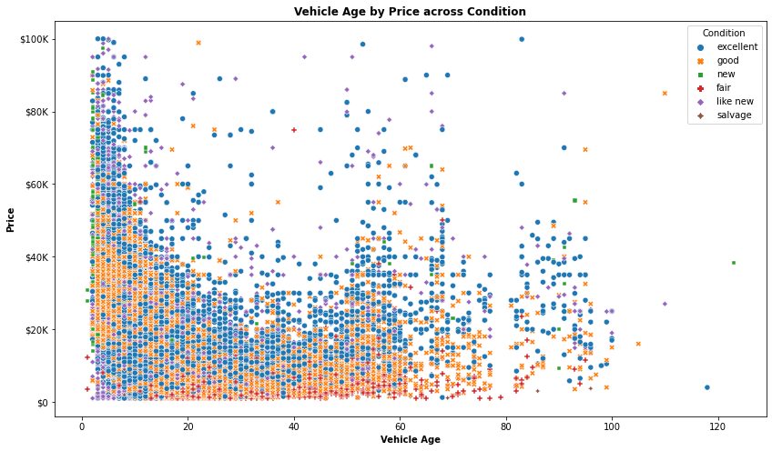

```python
# vehicle age by price across Condition
plt.figure(figsize=[14, 8])
sns.scatterplot(data = cars_df_clean, x = 'vehicle_age', y = 'price', hue = 'condition',
                style = 'condition')
plt.yticks([0, 20000, 40000, 60000, 80000, 100000],
          ['$0', '$20K', '$40K', '$60K', '$80K', '$100K'])
plt.xlabel('Vehicle Age', weight = 'bold')
plt.ylabel('Price', weight = 'bold')
plt.title('Vehicle Age by Price across Condition', weight = 'bold')
plt.legend(title = 'Condition');
```

> Approximately 80% of the vehicles are in good or excellent condition. This can be seen in the color scheme of the chart below. As one may expect, we also see vehicle price decrease as vehicle age increases for vehicles in good condition. For vehicles in excellent condition, we see more higher priced vehicles. I would expect this. A vintage vehicle in excellent condition tends to be high priced.

#### How does vehicle age affect price across vehicle drive type?

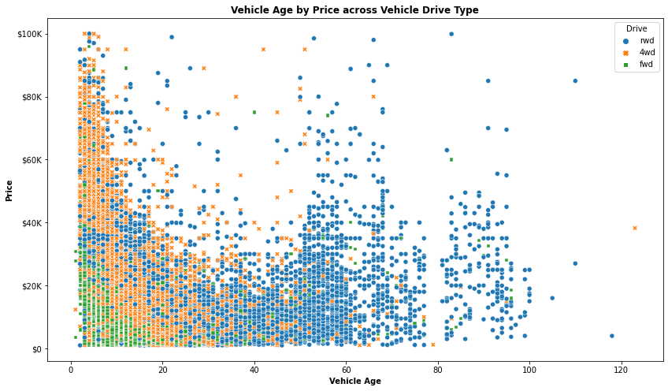

```python
# vehicle age by price across Condition
plt.figure(figsize=[14, 8])
sns.scatterplot(data = cars_df_clean, x = 'vehicle_age', y = 'price', hue = 'drive',
                style = 'drive')
plt.yticks([0, 20000, 40000, 60000, 80000, 100000],
          ['$0', '$20K', '$40K', '$60K', '$80K', '$100K'])
plt.xlabel('Vehicle Age', weight = 'bold')
plt.ylabel('Price', weight = 'bold')
plt.title('Vehicle Age by Price across Vehicle Drive Type', weight = 'bold')
plt.legend(title = 'Drive');
```

> We can see that four-wheel drive vehicle are prevelant from 0 to about 20 years of age, starting out high priced, then dropping as the vehicles age. Rear-wheel drive becomes more prevelant beyond 20 years and we see the price increase out beyond about 40 years.

#### Where are the highest priced vehicles located?

```python
# subset data to vehicles 85,000 dollars and above
max_price = cars_df_clean.price.max() # maximum vehicle price
high_price = cars_df_clean[cars_df_clean['price'] >= max_price*.85] # vehicle above 85% of max price
high_price.head()
```

|  | id | region | price | year | manufacturer | model | condition | fuel | odometer | title_status | transmission | drive | type | paint_color | state | lat | long | vehicle_age |
| --- | --- | --- | --- | --- | --- | --- | --- | --- | --- | --- | --- | --- | --- | --- | --- | --- | --- | --- |
| 346 | 7315259946 | birmingham | 98900 | 2001 | ferrari | 360 modena | good | gas | 20187.0 | clean | automatic | rwd | convertible | red | al | 34.586557 | -83.761243 | 22 |
| 5064 | 7316497061 | anchorage / mat-su | 98995 | 2017 | porsche | panamera turbo | excellent | gas | 38562.0 | clean | automatic | 4wd | hatchback | brown | ak | 61.218382 | -149.868922 | 6 |
| 5190 | 7315923139 | anchorage / mat-su | 98750 | 2019 | ford | f350 super duty lariat | like new | diesel | 47100.0 | clean | automatic | 4wd | truck | black | ak | 61.190000 | -149.893800 | 4 |
| 5223 | 7315656668 | anchorage / mat-su | 87995 | 2019 | ford | f350 drw | like new | diesel | 21183.0 | clean | automatic | 4wd | truck | grey | ak | 61.166252 | -149.857916 | 4 |
| 5944 | 7312397018 | anchorage / mat-su | 87995 | 2019 | ford | f350 drw | like new | diesel | 21183.0 | clean | automatic | 4wd | truck | grey | ak | 61.166252 | -149.857916 | 4 |

```python
# want data only for contiguous US states
non_contig = ['ak', 'hi']
high_price2 = high_price.query('state not in @non_contig')
```

```python
# check that ak and hi are not present
high_price2.state.value_counts()
```

```
ca    15
fl     7
or     7
ny     5
tx     4
id     4
ar     4
ok     4
ut     3
ma     3
pa     3
ga     3
nm     3
wa     3
il     2
sc     2
nv     2
oh     1
vt     1
al     1
ne     1
nh     1
mt     1
mn     1
md     1
me     1
ia     1
dc     1
co     1
wi     1
Name: state, dtype: int64
```

```python
# read in US map data
shape = gpd.read_file('cb_2018_us_state_20m/cb_2018_us_state_20m.shp')
shape.to_crs("EPSG:4326")
shape.head()
```

|  | STATEFP | STATENS | AFFGEOID | GEOID | STUSPS | NAME | LSAD | ALAND | AWATER | geometry |
| --- | --- | --- | --- | --- | --- | --- | --- | --- | --- | --- |
| 0 | 24 | 01714934 | 0400000US24 | 24 | MD | Maryland | 00 | 25151100280 | 6979966958 | MULTIPOLYGON (((-76.04621 38.02553, -76.00734 ... |
| 1 | 19 | 01779785 | 0400000US19 | 19 | IA | Iowa | 00 | 144661267977 | 1084180812 | POLYGON ((-96.62187 42.77925, -96.57794 42.827... |
| 2 | 10 | 01779781 | 0400000US10 | 10 | DE | Delaware | 00 | 5045925646 | 1399985648 | POLYGON ((-75.77379 39.72220, -75.75323 39.757... |
| 3 | 39 | 01085497 | 0400000US39 | 39 | OH | Ohio | 00 | 105828882568 | 10268850702 | MULTIPOLYGON (((-82.86334 41.69369, -82.82572 ... |
| 4 | 42 | 01779798 | 0400000US42 | 42 | PA | Pennsylvania | 00 | 115884442321 | 3394589990 | POLYGON ((-80.51989 40.90666, -80.51964 40.987... |

```python
# the map scale was throwing me off, so thanks to Jose Luis Ruiz and his Medium article
# that highlighted removing the noncontiguous US states and territories.
# Article: Plot maps from the US Census Bureau using Geopandas and Contextily in Python.
# Available at: https://medium.com/@jl_ruiz/plot-maps-from-the-us-census-bureau-using-geopandas-and-contextily-in-python-df787647ef77

non_continental = ['HI','VI','MP','GU', 'AK', 'AS','PR']
us49 = shape
for n in non_continental:
    us49 = us49[us49.STUSPS != n]
```

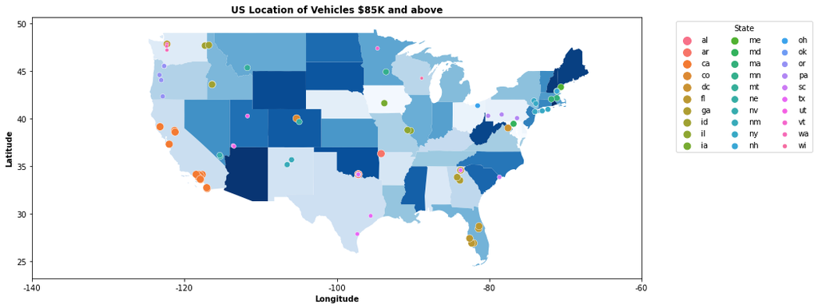

```python
fig, ax = plt.subplots(figsize=(14,8))

# draw the US noncontiguous 49 states
us49.plot(ax = ax, cmap = 'Blues', legend = True)

# plot vehicles over 85K points
sns.scatterplot(data = high_price2, x = "long", y = "lat", hue = 'state', ax = ax,
                size = 'state', sizes = (20, 100))
plt.xticks([-140, -120, -100, -80, -60],
          [-140, -120, -100, -80, -60])
plt.xlabel('Longitude', weight = 'bold')
plt.ylabel('Latitude', weight = 'bold')
plt.title('US Location of Vehicles $85K and above', weight = 'bold')
plt.legend(title = 'State', bbox_to_anchor=(1.05, 1.0), loc='upper left', ncol = 3)
plt.show();
```

> For vehicle over 85K, larger values numbers of vehicles are along the northeast, southeast, and west coasts.